# classtpx check on Buettner + Scialdone combined data

Kushal K Dey

February 24, 2016

## Overview

We apply the `classtpx` technique to classify the G1, G2 and S cells from two experiments in mouse RNA-seq. The dataset E-MTAB-2805 comprises of sequencing data on 96 cells each from G1, G2 and S phases of the cell cycle. Check [site](http://www.ebi.ac.uk/arrayexpress/experiments/E-MTAB-2805/). For the associated paper, check [Buettner et al 2015](http://www.nature.com/nbt/journal/v33/n2/full/nbt.3102.html).

We also have data on G1, G2 and S cells from the [Scialdone et al 2015](http://www.sciencedirect.com/science/article/pii/S1046202315300098) and the dataset ID is E-MTAB-3749 (FACS sorted data on G1, G2 and S cells).

Both the experiments were conducted on mice. In this paper, we shall build a classifier using the Buettner data to classify the Scialdone data and vice versa.

## classtpx Fitting

We first use the `classtpx` package to build a semi-supervised topic model using the Buettner data to build the classifier and use it on the Scialdone data as test data.

### Buettner et al 2015

```r
library(data.table)
G1_single <- data.frame(fread('../data/Marioni_data/G1_singlecells_counts.txt'), row.names=1);
G2M_single <- data.frame(fread('../data/Marioni_data/G2M_singlecells_counts.txt'), row.names=1);
S_single <- data.frame(fread('../data/Marioni_data/S_singlecells_counts.txt'), row.names=1);

cell_phases <- c(rep("G1", 96), rep("S", 96), rep("G2M", 96))
```

We filter out ERCC spike ins.

```r
ercc_start <- grep("ERCC", rownames(G1_single))[1]
G1_single <- G1_single[-(ercc_start:dim(G1_single)[1]),-(1:3)];
G2M_single <- G2M_single[-(ercc_start:dim(G2M_single)[1]),-(1:3)];
S_single <- S_single[-(ercc_start:dim(S_single)[1]),-(1:3)];
pooled_data <- t(cbind(G1_single, S_single, G2M_single));
```

### Scialdone et al 2015

```r
G1_data <- read.table("../data/Scialdone2015data/G1_htseq_count.txt");
G2M_data <- read.table("../data/Scialdone2015data/G2M_htseq_count.txt");
S_data <- read.table("../data/Scialdone2015data/S_htseq_count.txt");
facs_data <- cbind.data.frame(G1_data[,1], G1_data[,2], S_data[,2], G2M_data[,2]);
colnames(facs_data) <- c("genes", "G1.counts", "S.counts", "G2M.counts");
```

### Extracting common genes

```r
indices_intersect <- intersect(facs_data[,1], colnames(pooled_data))
matched_scialdone <-  match(indices_intersect, facs_data[,1]);
matched_buettner <- match(indices_intersect, colnames(pooled_data));

scialdone_data <- t(facs_data[matched_scialdone,-1]);
colnames(scialdone_data) <-  indices_intersect;

buettner_data <- pooled_data[,matched_scialdone];
colnames(buettner_data) <- indices_intersect;

pooled_data <- rbind(scialdone_data, buettner_data);
```

## Buettner data Training

```r
library(classtpx)
K <- 3;
known_samples <- 4:291;
class_labs <- c(rep(1,96), rep(2,96), rep(3,96));
```

### omega.fix method

```r
Topic_clus <- classtpx::class_topics(
    pooled_data,
    K,
    known_samples = known_samples,
    class_labs = class_labs,
    method="omega.fix",
    tol=0.01)

saveRDS(Topic_clus, "../rdas/scialdone_topic_fit_classtpx_omega_fix_buettner.rda")
```

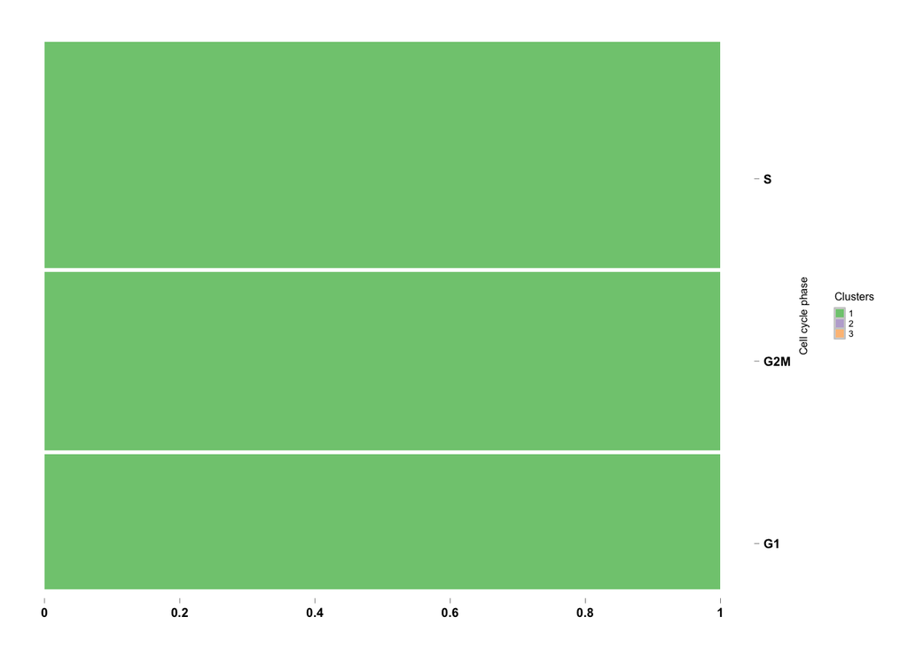

```r
Topic_clus <- readRDS("../rdas/scialdone_topic_fit_classtpx_omega_fix_buettner.rda")

omega <- Topic_clus$omega[-(4:291),];

omega <- rbind(omega[1,],omega[1,], omega[2,], omega[2,], omega[3,], omega[3,]);

annotation <- data.frame(
  sample_id = paste0("X", c(1:NROW(omega))),
  tissue_label = c(rep("G1", 2), rep("S", 2), rep("G2M", 2))
)

rownames(omega) <- annotation$sample_id;


CountClust::StructureGGplot(omega = omega,
                annotation = annotation,
                palette = RColorBrewer::brewer.pal(8, "Accent"),
                yaxis_label = "Cell cycle phase",
                order_sample = TRUE,
                axis_tick = list(axis_ticks_length = .1,
                                 axis_ticks_lwd_y = .1,
                                 axis_ticks_lwd_x = .1,
                                 axis_label_size = 7,
                                 axis_label_face = "bold"))
```

## Scialdone data Training

```r
library(classtpx)
K <- 3;
known_samples <- 1:3
class_labs <- 1:3;
```

### omega.fix method

```r
Topic_clus <- classtpx::class_topics(
    pooled_data,
    K,
    known_samples = known_samples,
    class_labs = class_labs,
    method="omega.fix",
    tol=0.01)

saveRDS(Topic_clus, "../rdas/buettner_topic_fit_classtpx_omega_fix_scialdone.rda")
```

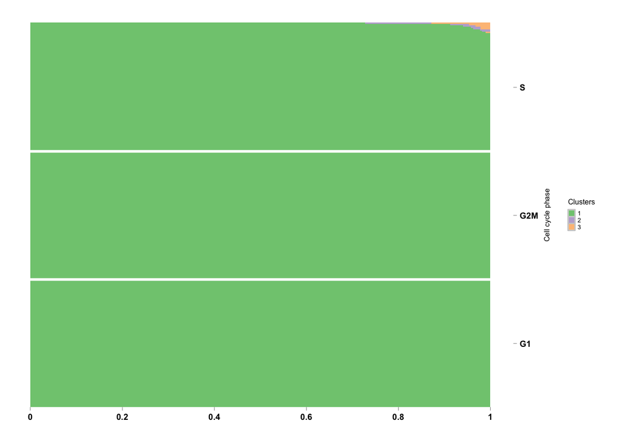

```r
Topic_clus <- readRDS("../rdas/buettner_topic_fit_classtpx_omega_fix_scialdone.rda")

omega <- Topic_clus$omega[-(1:3),];


annotation <- data.frame(
  sample_id = paste0("X", c(1:NROW(omega))),
  tissue_label = c(rep("G1", 96), rep("S", 96), rep("G2M", 96))
)

rownames(omega) <- annotation$sample_id;


CountClust::StructureGGplot(omega = omega,
                annotation = annotation,
                palette = RColorBrewer::brewer.pal(8, "Accent"),
                yaxis_label = "Cell cycle phase",
                order_sample = TRUE,
                axis_tick = list(axis_ticks_length = .1,
                                 axis_ticks_lwd_y = .1,
                                 axis_ticks_lwd_x = .1,
                                 axis_label_size = 7,
                                 axis_label_face = "bold"))
```

### theta.prior method

```r
Topic_clus <- classtpx::class_topics(
    pooled_data,
    K,
    known_samples = known_samples,
    class_labs = class_labs,
    method="theta.prior",
    tol=0.01)

saveRDS(Topic_clus, "../rdas/buettner_topic_fit_classtpx_theta_prior_scialdone.rda")
```

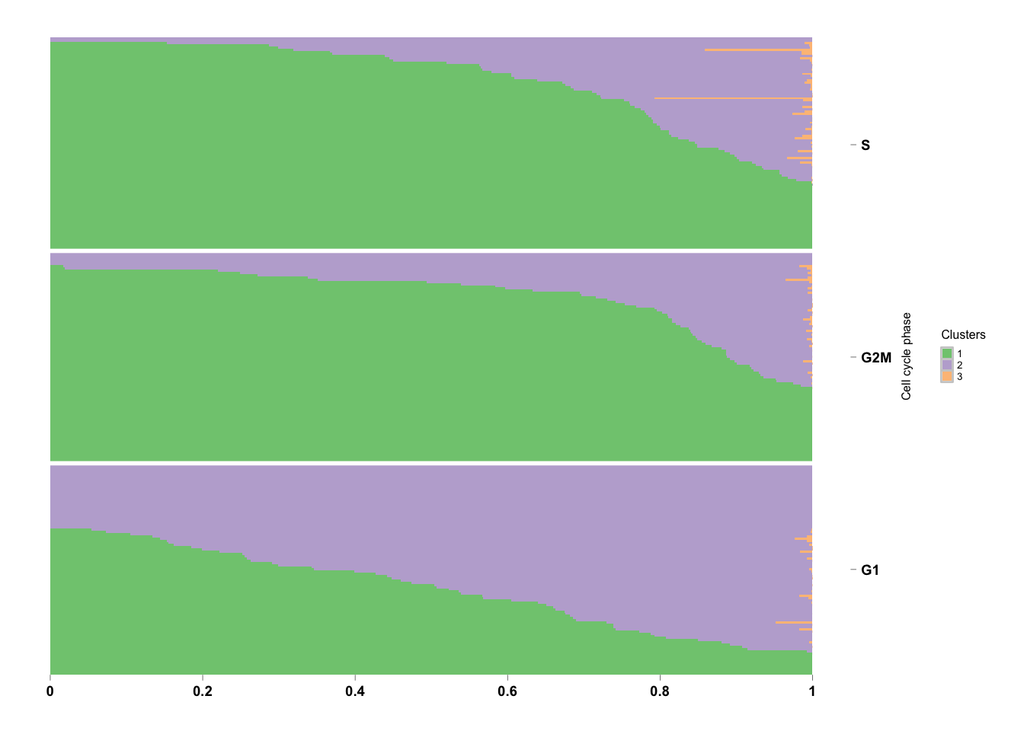

```r
Topic_clus <- readRDS("../rdas/buettner_topic_fit_classtpx_theta_prior_scialdone.rda")

omega <- Topic_clus$omega[-(1:3),];


annotation <- data.frame(
  sample_id = paste0("X", c(1:NROW(omega))),
  tissue_label = c(rep("G1", 96), rep("S", 96), rep("G2M", 96))
)

rownames(omega) <- annotation$sample_id;


CountClust::StructureGGplot(omega = omega,
                annotation = annotation,
                palette = RColorBrewer::brewer.pal(8, "Accent"),
                yaxis_label = "Cell cycle phase",
                order_sample = TRUE,
                axis_tick = list(axis_ticks_length = .1,
                                 axis_ticks_lwd_y = .1,
                                 axis_ticks_lwd_x = .1,
                                 axis_label_size = 7,
                                 axis_label_face = "bold"))
```

## Observations

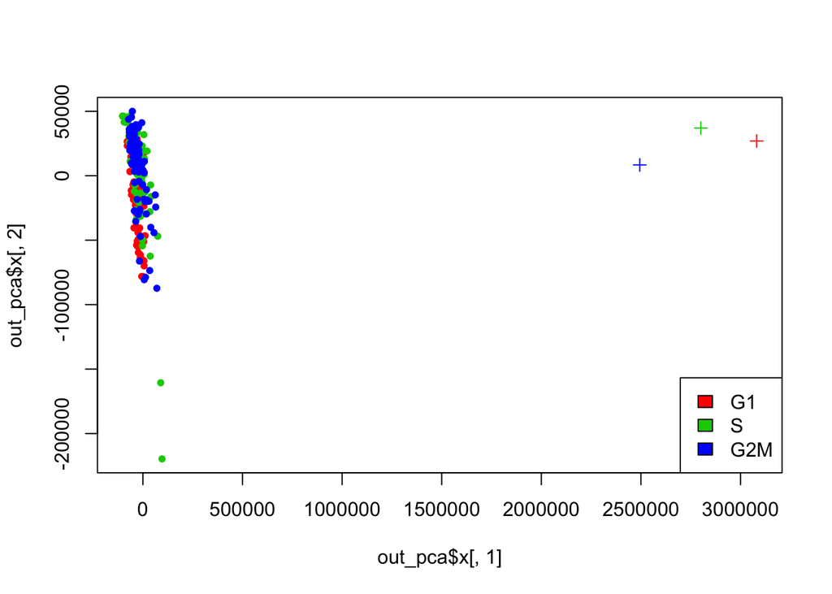

```r
color <- c(rep(2,96), rep(3, 96), rep(4,96), 2, 3, 4);
out_pca <- prcomp(rbind(buettner_data, scialdone_data));
plot(out_pca$x[,1], out_pca$x[,2], col=color, pch=c(rep(20,288),rep(3,3)))
legend("bottomright", c("G1","S", "G2M"), fill=c(2,3,4))
```

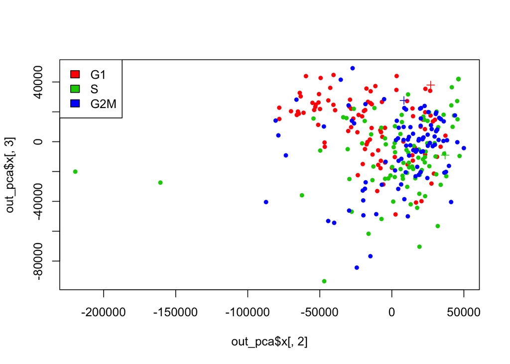

```r
plot(out_pca$x[,2], out_pca$x[,3], col=color, pch=c(rep(20,288),rep(3,3)))
legend("topleft", c("G1","S", "G2M"), fill=c(2,3,4))
```